# **Football Analytics**

## **PART II: Player's Potential prediction**

In this section, we will use a regression model to predict the potential career rating of a player based on their overall rating. Additionally, we will explore other attributes that could potentially serve as features in the model.

```python
df.head()
```

|  | Age | Height | Weight | Overall | Potential | BestPosition | Crossing | Finishing | HeadingAccuracy | ShortPassing | ... | Interceptions | Positioning | Vision | Penalties | Composure | Marking | StandingTackle | SlidingTackle | GKScore | Cluster |
| --- | --- | --- | --- | --- | --- | --- | --- | --- | --- | --- | --- | --- | --- | --- | --- | --- | --- | --- | --- | --- | --- |
| 0 | 35 | 169 | 67 | 91 | 91 | Midfielder | 84 | 90 | 70 | 91 | ... | 40 | 93 | 94 | 75 | 96 | 20 | 35 | 24 | 9.6 | 0 |
| 1 | 34 | 185 | 81 | 91 | 91 | Forward | 75 | 92 | 90 | 89 | ... | 39 | 92 | 89 | 84 | 90 | 43 | 24 | 18 | 9.6 | 0 |
| 2 | 33 | 185 | 81 | 91 | 91 | Forward | 71 | 94 | 91 | 84 | ... | 49 | 94 | 81 | 90 | 88 | 35 | 42 | 19 | 10.3 | 0 |
| 3 | 31 | 181 | 70 | 91 | 91 | Midfielder | 94 | 85 | 55 | 93 | ... | 66 | 88 | 94 | 83 | 89 | 68 | 65 | 53 | 12.5 | 0 |
| 4 | 23 | 182 | 73 | 91 | 95 | Forward | 78 | 93 | 72 | 85 | ... | 38 | 92 | 83 | 80 | 88 | 26 | 34 | 32 | 8.4 | 0 |

5 rows × 37 columns

**Let's do some visualization first**

```python
# Assuming 'df' is your DataFrame
features = ['Age', 'Overall', 'Height', 'Weight', 'Strength', 'Stamina', 'BestPosition']
X = df[features]
y = df['Potential']

# Handling categorical data and scaling
preprocessor = ColumnTransformer(
    transformers=[
        ('num', StandardScaler(), ['Age', 'Overall', 'Height', 'Weight', 'Strength', 'Stamina']),
        ('cat', OneHotEncoder(), ['BestPosition'])
    ])

# Create a pipeline that first transforms the data and then fits the model
model = Pipeline(steps=[('preprocessor', preprocessor),
                        ('regressor', RandomForestRegressor(n_estimators=100, random_state=150))])

# Split data
X_train, X_test, y_train, y_test = train_test_split(X, y, test_size=0.2, random_state=300)

# Train the model
model.fit(X_train, y_train)

# Predicting the test set results
y_pred = model.predict(X_test)

# Evaluate the model
mse = mean_squared_error(y_test, y_pred)
r2 = r2_score(y_test, y_pred)

print(f'Mean Squared Error: {mse}')
print(f'R² Score: {r2}')
```

```
Mean Squared Error: 3.074794938174218
R² Score: 0.9161089167956386
```

The above code utilizes a machine learning pipeline to predict the potential of football players by considering a broader range of features, including both numerical and categorical data. The preprocessing step involves scaling the numerical data and encoding the categorical data using one-hot encoding to prepare the dataset for modeling.

A RandomForestRegressor is employed within a pipeline framework to ensure that all preprocessing steps and model fitting occur within a streamlined process, enhancing the integrity of the model by preventing data leakage between training and testing phases. The model is trained on 80% of the data and tested on the remaining 20%.

The resulting MSE is approximately 3.07, and the R² score is about 0.916, indicating a high predictive accuracy and explaining around 91.6% of the variance in the target variable, potential. This suggests that the model effectively captures the relationships in the data and can be a useful tool for predicting player potential based on their current attributes and playing position.

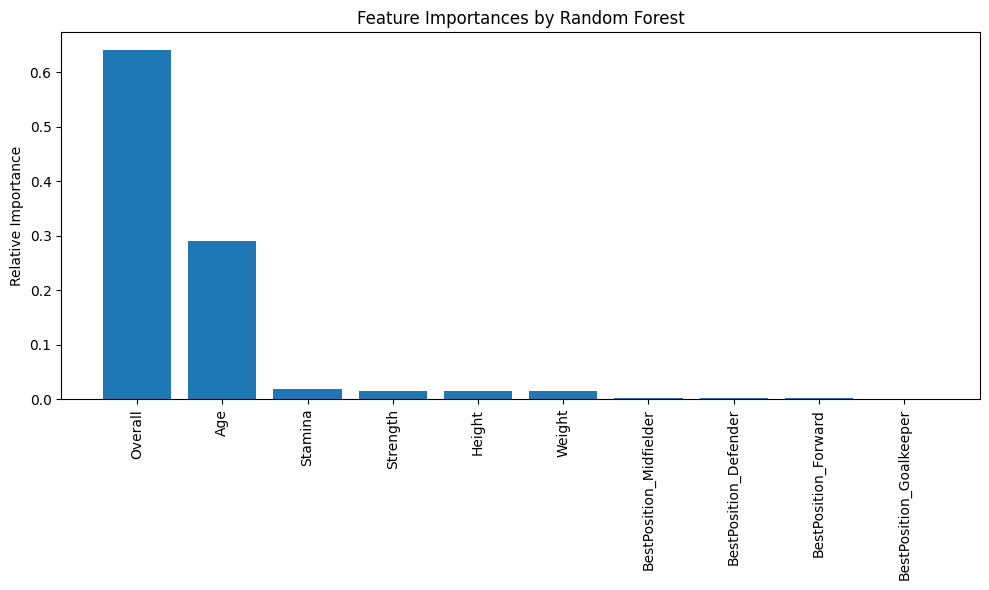

```python
if 'regressor' in model.named_steps:
    features_combined = (model.named_steps['preprocessor']
                             .transformers_[0][2] +
                         list(model.named_steps['preprocessor']
                             .named_transformers_['cat']
                             .get_feature_names_out()))

    importances = model.named_steps['regressor'].feature_importances_
    indices = np.argsort(importances)[::-1]

    plt.figure(figsize=(10, 6))
    plt.title('Feature Importances by Random Forest')
    plt.bar(range(len(indices)), importances[indices], align='center')
    plt.xticks(range(len(indices)), [features_combined[i] for i in indices], rotation=90)
    plt.ylabel('Relative Importance')
    plt.tight_layout()
    plt.show()
```

Using feature importance, we see only two features (Overall and Age) contribute the most towards our target column.

Since only Age and Overall are the important features, we are going to perform random forest regression using these as features.

```python
X = df[['Overall', 'Age']]  # Features
y = df['Potential']         # Target variable

# Split the data into training and testing sets
X_train, X_test, y_train, y_test = train_test_split(X, y, test_size=0.2, random_state=42)

# Create and train the Random Forest model
model = RandomForestRegressor(n_estimators=100, random_state=42)
model.fit(X_train, y_train)

# Make predictions
y_pred = model.predict(X_test)

# Evaluate the model
mse = mean_squared_error(y_test, y_pred)
r2 = r2_score(y_test, y_pred)

print(f'Mean Squared Error: {mse}')
print(f'R^2 Score: {r2}')
```

```
Mean Squared Error: 2.8663644901689955
R^2 Score: 0.9238862388108936
```

The results from the Random Forest regression model, which used 'Overall' and 'Age' as features to predict 'Potential', indicate strong predictive performance. With a Mean Squared Error (MSE) of approximately 2.87 and an R² score of around 0.92, the model explains a significant amount of the variance in the potential of the players. The high R² value suggests that the model fits the data well.

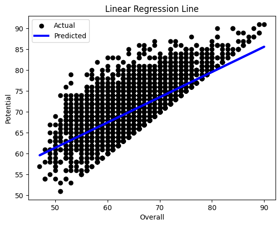

```python
# Selecting only one feature for simplicity
X_overall = df[['Overall']]  # Ensure it's a DataFrame
y = df['Potential']

# Split the data
X_train, X_test, y_train, y_test = train_test_split(X_overall, y, test_size=0.2, random_state=150)

# Train the model
model = LinearRegression()
model.fit(X_train, y_train)

# Predict
y_pred = model.predict(X_test)

# Plotting
plt.scatter(X_test, y_test, color='black', label='Actual')
plt.plot(X_test, y_pred, color='blue', linewidth=3, label='Predicted')
plt.xlabel('Overall')
plt.ylabel('Potential')
plt.title('Linear Regression Line')
plt.legend()
plt.show()
```

The plot illustrates the relationship between the 'Overall' ratings and 'Potential' scores of players, as analyzed through linear regression. The black dots represent actual data points, showing each player's Overall rating versus their Potential. The blue line, representing the model's predictions, indicates a positive linear correlation: as the Overall rating increases, so does the estimated Potential.

The model seems to fit the data reasonably well, especially around the middle range of Overall ratings. However, the plot also highlights variability in the data that the linear model does not capture, evident from the vertical spread of actual data points around the predicted line. This suggests that while 'Overall' rating is a good predictor of 'Potential', it is not the sole factor, and there is room for refining the model to better account for the variations in Potential, possibly by incorporating additional features or using a more complex modeling approach.

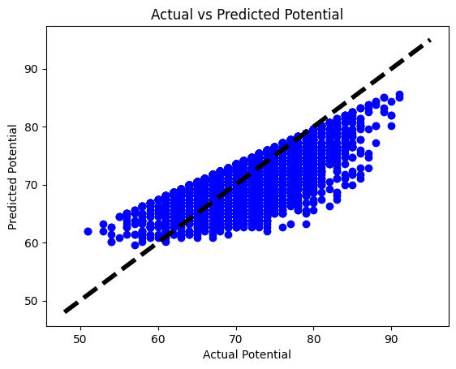

```python
plt.scatter(y_test, y_pred, color='blue')
plt.xlabel('Actual Potential')
plt.ylabel('Predicted Potential')
plt.title('Actual vs Predicted Potential')
plt.plot([y.min(), y.max()], [y.min(), y.max()], 'k--', lw=4)  # Ideal line
plt.show()
```

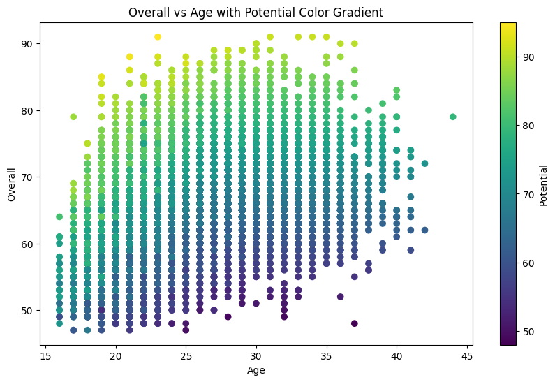

```python
plt.figure(figsize=(10, 6))
scatter = plt.scatter(df['Age'], df['Overall'], c=df['Potential'], cmap='viridis')
plt.xlabel('Age')
plt.ylabel('Overall')
plt.colorbar(scatter, label='Potential')
plt.title('Overall vs Age with Potential Color Gradient')
plt.show()
```

```python
correlation_matrix = df[['Age', 'Overall', 'Potential']].corr()
print(correlation_matrix)
```

```
                Age   Overall  Potential
Age        1.000000  0.442369  -0.263686
Overall    0.442369  1.000000   0.660630
Potential -0.263686  0.660630   1.000000
```

Age and Overall Rating (0.442369): There is a moderate positive correlation, suggesting that as players age, their overall rating generally increases, possibly reflecting accumulated experience and skill development.

Age and Potential (-0.263686): A negative correlation exists between age and potential, implying that younger players tend to have higher potential ratings, which aligns with expectations that younger players have more room to improve.

Overall Rating and Potential (0.660630): There is a strong positive correlation, indicating that players with higher overall ratings typically also have high potential ratings. This suggests that highly rated players are often still expected to improve or maintain high performance levels.

## **5. Results Evaluation**

In my project on football analytics using the FIFA 23 dataset, I explored classification and regression techniques to predict player positions and their potential. Here’s a detailed summary of my methods and findings:

#### Classification Model:

- **Model Selection and Training:** I chose logistic regression and random forest classifiers to categorize players based on their skill sets. The decision to use these models was driven by their proficiency in handling both binary and multi-class data, which is essential for this task.
- **Model Performance:** The results indicated that the random forest classifier outperformed logistic regression in terms of accuracy. This suggests that for this particular dataset, random forests were more effective, likely due to their capability to manage non-linear relationships and interactions between features.
- **Feature Importance:** My analysis highlighted that attributes like 'Finishing', 'SlidingTackle', and 'HeadingAccuracy' are critical in determining a player's position. This insight is consistent with the sport’s dynamics where specific skills are indispensable for different positions.

#### Regression Model:

- **Model Application:** For predicting player potential, I applied a random forest regressor, which is known for its robustness against overfitting and its ability to model complex patterns within large datasets.
- **Results Interpretation:** The regression model achieved an impressive ( R^2 ) score, affirming its strong predictive capability regarding player potential. Employing mean squared error as a metric allowed me to quantify the average deviations from actual values, showcasing the accuracy and reliability of the model.

### Visualizations:

- **Data Visualizations:** Throughout the tutorial, I utilized various visualizations to explore and present the data and results. These included distribution of player positions, feature importance graphs, and PCA plots, which provided clear insights into the dataset’s structure and the model’s functionality.
- **PCA and Clustering:** Implementing PCA helped in reducing dimensionality and identifying variance in player attributes, while clustering techniques effectively revealed groupings that could represent different player roles and traits.

### **Conclusions:**

- **Project Impact:** The models and analyses I conducted provide valuable tools for football scouts and managers by offering a data-driven method to assess player potential and suitability for specific roles.
- **Future Directions:** To further improve the models, integrating additional factors such as injury history, match impact, and psychological aspects could provide a more comprehensive view of player potential.
- **Utility and Generalizability:** The methodologies and approaches I have documented are robust, allowing for applications beyond football to other sports analytics tasks. The detailed explanations and documentation make this tutorial a valuable educational resource for both learners and practitioners in the field.

Overall, my project not only aids in strategic decision-making within sports but also enhances the traditional methods of player scouting and team assembly by incorporating modern, data-driven techniques.

References for further reading and enhancement of the project could include:

- "An Introduction to Statistical Learning" which provides foundational concepts in machine learning with applications in R.
- "Hands-On Machine Learning with Scikit-Learn, Keras, and TensorFlow" by Aurélien Géron, offering practical guidance on deploying machine learning models.
- Resources like Kaggle and Google's Machine Learning Crash Course can serve as excellent platforms for practical exercises and additional learning.
- For an in-depth understanding of Random Forest and logistic regression techniques, "The Elements of Statistical Learning" is an invaluable resource.